# Appendix for Kailing et al. Sex biased Pd Infection Ms

**OVERVIEW:**

Each model is parameterized in relation to the reference level or intercept (F = Female; MYLU = little brown bat) and each parameter estimate represents the difference from this reference level, incorporating the effect of each fixed effect (i.e., species, sex, date, etc). An example in Model 1: the “Estimate” for sexM listed in the output summary is the inverse logit fraction of the male little brown bat population infected relative to females.

# 1 How does **prevalence (gd)** differ by sex in early hibernation?

## 1.1 Model 1: Species specific differences by sex - sex and species as fixed effects; site as random effect

```
Generalized linear mixed model fit by maximum likelihood (Laplace
  Approximation) [glmerMod]
 Family: binomial  ( logit )
Formula: gd ~ species + sex + (1 | site)
   Data: est.dat
Control: glmerControl(optimizer = "bobyqa", optCtrl = list(maxfun = 1e+05))
 Subset: season2 == "h.earl"

     AIC      BIC   logLik deviance df.resid
   694.2    727.2   -340.1    680.2      813

Scaled residuals:
     Min       1Q   Median       3Q      Max
-10.7876  -0.2530   0.2482   0.4296   2.8296

Random effects:
 Groups Name        Variance Std.Dev.
 site   (Intercept) 1.463    1.209
Number of obs: 820, groups:  site, 34

Fixed effects:
            Estimate Std. Error z value Pr(>|z|)
(Intercept)   3.2105     0.3655   8.784  < 2e-16 ***
speciesMYSE  -0.7737     0.5323  -1.454  0.14606
speciesPESU  -1.9343     0.3013  -6.419 1.37e-10 ***
speciesMYSO  -3.6971     0.7366  -5.019 5.19e-07 ***
speciesEPFU  -2.4431     0.3239  -7.544 4.56e-14 ***
sexM         -0.6370     0.2234  -2.851  0.00435 **
---
Signif. codes:  0 '***' 0.001 '**' 0.01 '*' 0.05 '.' 0.1 ' ' 1

Correlation of Fixed Effects:
            (Intr) spMYSE spPESU spMYSO spEPFU
speciesMYSE -0.116
speciesPESU -0.496  0.175
speciesMYSO -0.292  0.038  0.195
speciesEPFU -0.415  0.098  0.346  0.112
sexM        -0.510  0.047  0.240  0.036  0.284
```

## 1.2 Check performance of Model 1 against other model structures. All models include site as a random effect.

- ‘null’ model: gd~1

```
|   |Modnames                 |  K|      AIC| Delta_AIC|  ModelLik|     AICWt|        LL|    Cum.Wt|
|:--|:------------------------|--:|--------:|---------:|---------:|---------:|---------:|---------:|
|4  |species+sex              |  7| 694.2394|  0.000000| 1.0000000| 0.7948148| -340.1197| 0.7948148|
|5  |species * sex            | 11| 697.3470|  3.107562| 0.2114470| 0.1680612| -337.6735| 0.9628760|
|3  |species                  |  6| 700.5184|  6.278981| 0.0433048| 0.0344193| -344.2592| 0.9972953|
|2  |sex + random eff:species |  4| 705.6056| 11.366238| 0.0034029| 0.0027047| -348.8028| 1.0000000|
|1  |null                     |  2| 785.5326| 91.293252| 0.0000000| 0.0000000| -390.7663| 1.0000000|
```

## 1.3 Check support for interaction between sex and species

- prA: sex+species
- prB: sex*species

```
Data: est.dat
Subset: season2 == "h.earl"
Models:
pr.null: gd ~ 1 + (1 | site)
prA: gd ~ species + sex + (1 | site)
prB: gd ~ species * sex + (1 | site)
        npar    AIC    BIC  logLik deviance    Chisq Df Pr(>Chisq)
pr.null    2 785.53 794.95 -390.77   781.53
prA        7 694.24 727.20 -340.12   680.24 101.2933  5     <2e-16 ***
prB       11 697.35 749.15 -337.67   675.35   4.8924  4     0.2985
---
Signif. codes:  0 '***' 0.001 '**' 0.01 '*' 0.05 '.' 0.1 ' ' 1
```

## 1.4 *Result:*

- ∆AIC of species + sex model compared to other models is **>-3.1**. Reported model is best supported.
- There is no clear support for interaction between species and sex.
- Across species, female bats have higher prevalence in early hibernation than males.

## 1.5 View prevalence plot (Figure 1)

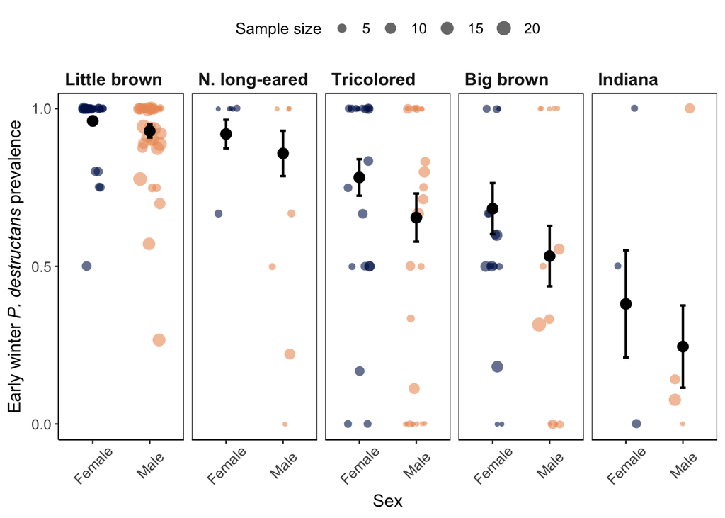

# 2 How does **infection severity (fungal loads; lgdL)** differ by host sex?

## 2.1 Model 2: Population-level sex differences in fungal loads by species *over winter* - sex, species, and date as fixed effects; site as random effect

- ‘*pdate.scale*’ is a date variable converted to monthly units then scaled to start at Day 0.

```
Linear mixed model fit by REML ['lmerMod']
Formula: lgdL ~ species * pdate.scale + sex * pdate.scale + (1 | site)
   Data: est.dat

REML criterion at convergence: 4161.4

Scaled residuals:
    Min      1Q  Median      3Q     Max
-5.2371 -0.5644  0.0152  0.6149  3.8040

Random effects:
 Groups   Name        Variance Std.Dev.
 site     (Intercept) 0.3644   0.6037
 Residual             0.9223   0.9603
Number of obs: 1463, groups:  site, 42

Fixed effects:
                        Estimate Std. Error t value
(Intercept)             -3.52333    0.13261 -26.569
speciesMYSE             -0.42879    0.26808  -1.600
speciesPESU             -0.27203    0.12427  -2.189
speciesMYSO             -1.06358    0.33545  -3.171
speciesEPFU             -1.14643    0.18118  -6.328
pdate.scale              0.40523    0.02659  15.238
sexM                    -0.48994    0.09288  -5.275
speciesMYSE:pdate.scale  0.23282    0.13602   1.712
speciesPESU:pdate.scale  0.06707    0.03719   1.803
speciesMYSO:pdate.scale -0.21225    0.07366  -2.881
speciesEPFU:pdate.scale -0.04564    0.04777  -0.955
pdate.scale:sexM         0.09528    0.02704   3.523

Correlation of Fixed Effects:
            (Intr) spMYSE spPESU spMYSO spEPFU pdt.sc sexM   sMYSE: sPESU:
speciesMYSE -0.109
speciesPESU -0.301  0.096
speciesMYSO -0.078  0.033  0.076
speciesEPFU -0.267  0.063  0.170  0.034
pdate.scale -0.522  0.126  0.294  0.089  0.271
sexM        -0.495  0.065  0.172 -0.013  0.214  0.597
spcsMYSE:p.  0.066 -0.564 -0.036 -0.023 -0.044 -0.138 -0.035
spcsPESU:p.  0.200 -0.068 -0.701 -0.047 -0.146 -0.471 -0.160  0.075
spcsMYSO:p.  0.074 -0.035 -0.071 -0.862 -0.050 -0.162  0.000  0.037  0.112
spcsEPFU:p.  0.195 -0.056 -0.139 -0.029 -0.859 -0.364 -0.192  0.058  0.215
pdt.scl:sxM  0.404 -0.057 -0.160  0.009 -0.176 -0.739 -0.801  0.055  0.233
            sMYSO: sEPFU:
speciesMYSE
speciesPESU
speciesMYSO
speciesEPFU
pdate.scale
sexM
spcsMYSE:p.
spcsPESU:p.
spcsMYSO:p.
spcsEPFU:p.  0.067
pdt.scl:sxM -0.007  0.230
```

- Calculate p-value from t-value for sex difference estimates

```
[1] 1.534453e-07
```

## 2.2 Check performance of Model 2 against other model structures. All models include site as a random effect.

- ‘null’ model: lgdL~1

```
|   |Modnames                  |  K|      AIC| Delta_AIC| ModelLik|     AICWt|        LL|    Cum.Wt|
|:--|:-------------------------|--:|--------:|---------:|--------:|---------:|---------:|---------:|
|6  |species * date+sex * date | 14| 4146.966|    0.0000| 1.00e+00| 0.9999021| -2059.483| 0.9999021|
|5  |species+date+sex          |  9| 4165.429|   18.4635| 9.79e-05| 0.0000979| -2073.715| 1.0000000|
|4  |species+sex               |  8| 4903.466|  756.5003| 0.00e+00| 0.0000000| -2443.733| 1.0000000|
|2  |sex + random eff:species  |  5| 4916.087|  769.1211| 0.00e+00| 0.0000000| -2453.043| 1.0000000|
|3  |species                   |  7| 4918.534|  771.5681| 0.00e+00| 0.0000000| -2452.267| 1.0000000|
|1  |null                      |  3| 5037.020|  890.0540| 0.00e+00| 0.0000000| -2515.510| 1.0000000|
```

## 2.3 *Result:*

- ∆AIC of species * date + sex * date model compared to other models is **>-18.4**. Reported model is best supported.
- By early hibernation, females have more severe infections compared to males but appear to have lower fungal growth. However, this may be driven by a survival bias (see Supp Analysis 1; Figure S1A).

## 2.4 View fungal loads plot (Figure 2a-f)

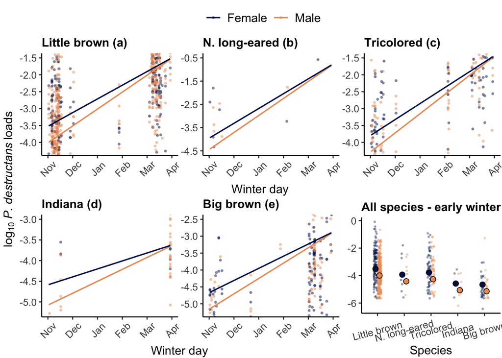

# 3 Do sex-biased infections affect **survival** or **population structure**?

## 3.1 Model 3A: Effect of host sex on probability of re-sighting (e.g., apparent survival) - sex as fixed effect; site as random effect

```
Generalized linear mixed model fit by maximum likelihood (Laplace
  Approximation) [glmerMod]
 Family: binomial  ( logit )
Formula: RecapturedSameYearYN.x ~ sex.x + (1 | site2.x)
   Data: wr
Control: glmerControl(optimizer = "bobyqa", optCtrl = list(maxfun = 1e+05))

     AIC      BIC   logLik deviance df.resid
   273.7    284.1   -133.8    267.7      237

Scaled residuals:
    Min      1Q  Median      3Q     Max
-2.0670 -0.6478 -0.2928  0.7152  5.1007

Random effects:
 Groups  Name        Variance Std.Dev.
 site2.x (Intercept) 1.915    1.384
Number of obs: 240, groups:  site2.x, 13

Fixed effects:
            Estimate Std. Error z value Pr(>|z|)
(Intercept)  -1.1691     0.5366  -2.179   0.0293 *
sex.xM        0.8548     0.3788   2.257   0.0240 *
---
Signif. codes:  0 '***' 0.001 '**' 0.01 '*' 0.05 '.' 0.1 ' ' 1

Correlation of Fixed Effects:
       (Intr)
sex.xM -0.514
```

### 3.1.1 Check performance of Model 3A compared to null. Both models include site as a random effect.

- ‘null’ model: winter recap~1

```
|   |Modnames |  K|      AIC| Delta_AIC|  ModelLik|     AICWt|        LL|    Cum.Wt|
|:--|:--------|--:|--------:|---------:|---------:|---------:|---------:|---------:|
|2  |sex      |  3| 273.6612|  0.000000| 1.0000000| 0.8287891| -133.8306| 0.8287891|
|1  |null     |  2| 276.8154|  3.154139| 0.2065796| 0.1712109| -136.4077| 1.0000000|
```

### 3.1.2 *Result:*

- Including sex improves the ability to predict whether a bat will be re-sighted in late hibernation.
- Female little brown bats are less likely to survive over winter than males.

## 3.2 Model 3B: Effect of years since pathogen invasion on the proportion of bats that are female in late hibernation - years since disease invasion as fixed effect; site as random effect

```
Generalized linear mixed model fit by maximum likelihood (Laplace
  Approximation) [glmerMod]
 Family: binomial  ( logit )
Formula: sex2 ~ ysw + (1 | site)
   Data: late
Control: glmerControl(optimizer = "bobyqa", optCtrl = list(maxfun = 1e+05))

     AIC      BIC   logLik deviance df.resid
   295.0    305.5   -144.5    289.0      244

Scaled residuals:
    Min      1Q  Median      3Q     Max
-0.9210 -0.6519 -0.5169  1.2315  2.2526

Random effects:
 Groups Name        Variance Std.Dev.
 site   (Intercept) 0.101    0.3178
Number of obs: 247, groups:  site, 14

Fixed effects:
            Estimate Std. Error z value Pr(>|z|)
(Intercept)   0.1780     0.5078   0.350   0.7260
ysw          -0.3628     0.1734  -2.092   0.0365 *
---
Signif. codes:  0 '***' 0.001 '**' 0.01 '*' 0.05 '.' 0.1 ' ' 1

Correlation of Fixed Effects:
    (Intr)
ysw -0.939
```

### 3.2.1 Check performance of Model3B compared to null. Both models include site as a random effect.

- ‘null’ model: sex~1

```
|   |Modnames |  K|      AIC| Delta_AIC|  ModelLik|     AICWt|        LL|    Cum.Wt|
|:--|:--------|--:|--------:|---------:|---------:|---------:|---------:|---------:|
|2  |ysw      |  3| 295.0053|  0.000000| 1.0000000| 0.7351623| -144.5026| 0.7351623|
|1  |null     |  2| 297.0472|  2.041948| 0.3602439| 0.2648377| -146.5236| 1.0000000|
```

### 3.2.2 *Result:*

- Including years since white-nose syndrome invasion improves the ability to predict whether a bat sampled in late hibernation will be female.
- The probability of sampling a female decreased with years since *P. destructans* invasion.

## 3.3 View little brown bat impacts plot (Figure 3A-B)

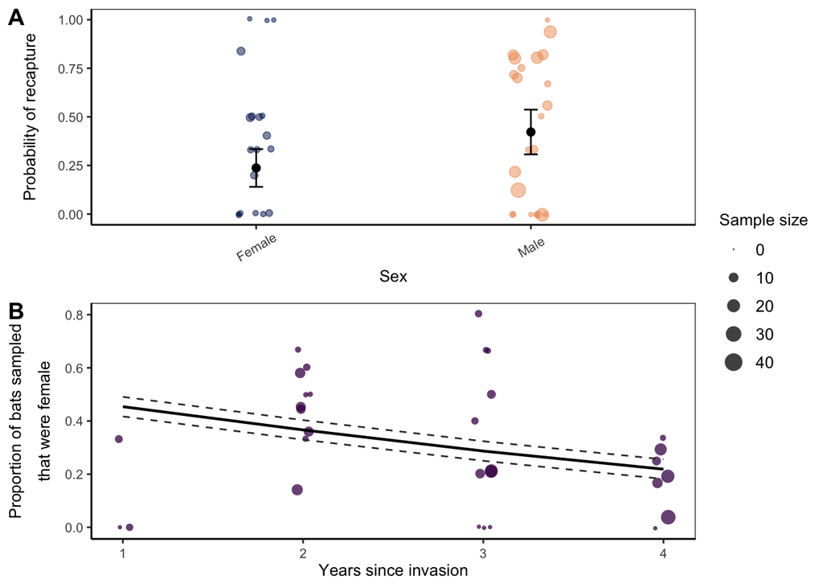

# 4 Does **autumn swarm activity** differ by sex?

## 4.1 Model 4: Sex differences in autumn swarm - sex and site as fixed effects; individual ID as random effect

```
Generalized linear mixed model fit by maximum likelihood (Laplace
  Approximation) [glmerMod]
 Family: binomial  ( logit )
Formula: prop.act ~ sex + site2 + (1 | pit_id)
   Data: fall
Weights: rdr.nt
Control: glmerControl(optimizer = "bobyqa", optCtrl = list(maxfun = 1e+05))

     AIC      BIC   logLik deviance df.resid
  1973.4   1993.6   -981.7   1963.4      420

Scaled residuals:
    Min      1Q  Median      3Q     Max
-3.4381 -0.6279 -0.0167  0.3083  3.1567

Random effects:
 Groups Name        Variance Std.Dev.
 pit_id (Intercept) 1.298    1.139
Number of obs: 425, groups:  pit_id, 373

Fixed effects:
            Estimate Std. Error z value Pr(>|z|)
(Intercept)  -4.1129     0.1618 -25.412  < 2e-16 ***
sexM          1.4007     0.1710   8.189 2.63e-16 ***
site2A MIE    1.1327     0.1795   6.311 2.77e-10 ***
site2DEN OC  -0.2998     0.1816  -1.651   0.0988 .
---
Signif. codes:  0 '***' 0.001 '**' 0.01 '*' 0.05 '.' 0.1 ' ' 1

Correlation of Fixed Effects:
            (Intr) sexM   s2AMIE
sexM        -0.759
site2A MIE  -0.243 -0.157
site2DEN OC -0.362  0.018  0.319
```

## 4.2 Check performance of Model 4 compared to other model structures.

- ‘null’ model: proportion of nights active~1.

```
|   |Modnames |  K|      AIC| Delta_AIC| ModelLik| AICWt|         LL| Cum.Wt|
|:--|:--------|--:|--------:|---------:|--------:|-----:|----------:|------:|
|3  |sex+site |  5| 1973.377|   0.00000|        1|     1|  -981.6887|      1|
|2  |sex      |  3| 2018.967|  45.58928|        0|     0| -1006.4834|      1|
|1  |null     |  2| 2093.959| 120.58183|        0|     0| -1044.9797|      1|
```

## 4.3 *Result:*

- The additive effects of sex and site is better supported over models including sex alone or the null model.
- Female bats spend fewer nights active than males throughout autumn.

## 4.4 View autumn activity plot (Figure 4)

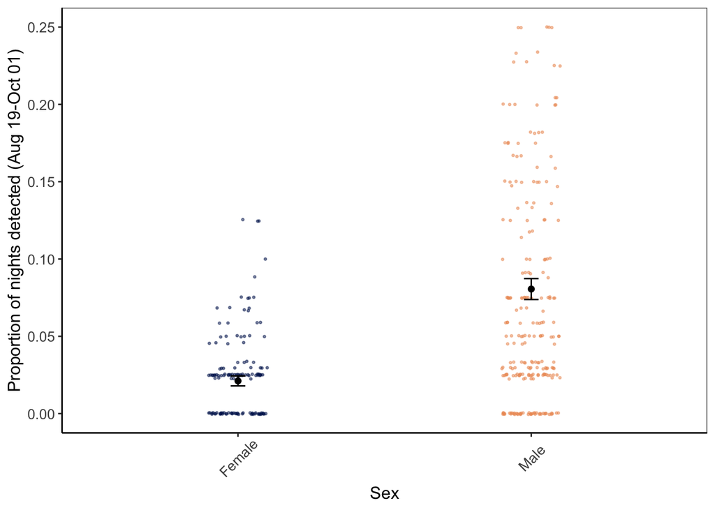

# 5 Supplemental analyses and figures

## 5.1 Explore relationships between survival and fungal loads by sex

### 5.1.1 Model S1A: Do female and male **changes in fungal loads** differ over winter? sex as fixed effect; site as random effect

```
Linear mixed model fit by REML ['lmerMod']
Formula: log_Dloads2 ~ sex.x + (1 | site2.x)
   Data: wr1

REML criterion at convergence: 130.3

Scaled residuals:
    Min      1Q  Median      3Q     Max
-3.4156 -0.5598 -0.1691  0.5704  2.9022

Random effects:
 Groups   Name        Variance Std.Dev.
 site2.x  (Intercept) 0.3437   0.5862
 Residual             0.1672   0.4090
Number of obs: 97, groups:  site2.x, 10

Fixed effects:
            Estimate Std. Error t value
(Intercept) -1.24637    0.21081  -5.912
sex.xM      -0.09011    0.11819  -0.762

Correlation of Fixed Effects:
       (Intr)
sex.xM -0.372
```

- Calculate p-value from t-value for change in fungal loads estimates

```
[1] 0.4481692
```

### 5.1.2 View change in fungal loads plot (Supp Figure 1A)

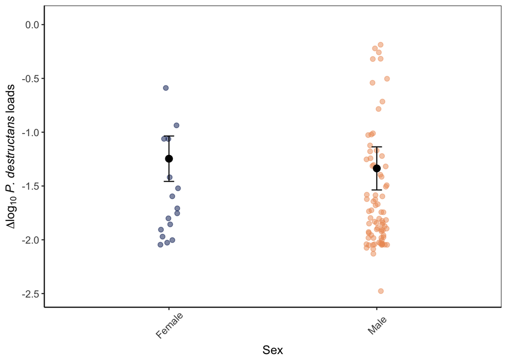

### 5.1.3 Model S1B: What is the relationship between **early winter loads and recapture frequency** of females and males? sex and recapture status as fixed effects

```
Call:
lm(formula = lgdL.x ~ sex.x + RecapturedSameYearYN.x, data = wr)

Residuals:
     Min       1Q   Median       3Q      Max
-2.78008 -0.68981  0.06046  0.65047  2.82307

Coefficients:
                        Estimate Std. Error t value Pr(>|t|)
(Intercept)              -2.8736     0.1511 -19.017  < 2e-16 ***
sex.xM                   -0.6194     0.1626  -3.810 0.000177 ***
RecapturedSameYearYN.x1  -0.4181     0.1386  -3.016 0.002837 **
---
Signif. codes:  0 '***' 0.001 '**' 0.01 '*' 0.05 '.' 0.1 ' ' 1

Residual standard error: 1.067 on 237 degrees of freedom
Multiple R-squared:  0.09897,   Adjusted R-squared:  0.09136
F-statistic: 13.02 on 2 and 237 DF,  p-value: 4.333e-06
```

### 5.1.4 View plot of recapture status and sex over early hibernation fungal loads (Supp Figure 1B)

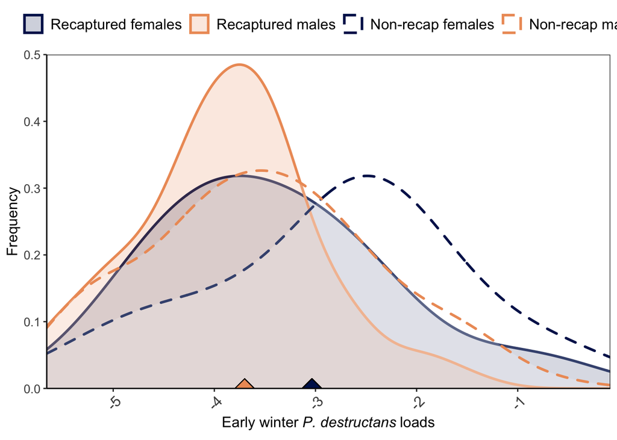

### 5.1.5 *Result:*

- Fungal growth rates over winter are similar between males and females that survive WNS.
- Bats that survive winter begin hibernation with lower fungal loads than bats that do not survive.

## 5.2 Do differences in early hibernation roosting temperature explain female biased infections? (Supp Fig 2A)

### 5.2.1 Are there sex differences in roosting temperature among species?

```
Linear mixed model fit by REML ['lmerMod']
Formula: temp ~ species * sex + (1 | site)
   Data: easpp.t

REML criterion at convergence: 2021.8

Scaled residuals:
    Min      1Q  Median      3Q     Max
-5.1106 -0.4507  0.0025  0.5422  3.3058

Random effects:
 Groups   Name        Variance Std.Dev.
 site     (Intercept) 3.759    1.939
 Residual             1.075    1.037
Number of obs: 660, groups:  site, 25

Fixed effects:
                 Estimate Std. Error t value
(Intercept)        8.8851     0.4083  21.762
speciesMYSE        0.1049     0.3681   0.285
speciesPESU        0.5492     0.1909   2.876
speciesEPFU       -1.0462     0.1940  -5.391
sexM               0.1343     0.1209   1.111
speciesMYSE:sexM  -0.4989     0.4461  -1.118
speciesPESU:sexM  -0.1744     0.2295  -0.760
speciesEPFU:sexM  -0.8367     0.2534  -3.302

Correlation of Fixed Effects:
            (Intr) spMYSE spPESU spEPFU sexM   sMYSE: sPESU:
speciesMYSE -0.070
speciesPESU -0.180  0.180
speciesEPFU -0.164  0.147  0.329
sexM        -0.211  0.234  0.486  0.469
spcsMYSE:sM  0.058 -0.783 -0.129 -0.140 -0.270
spcsPESU:sM  0.119 -0.118 -0.707 -0.245 -0.531  0.146
spcsEPFU:sM  0.096 -0.104 -0.209 -0.657 -0.472  0.124  0.245
```

#### 5.2.1.1 View model predicted means (emmean) and standard errors (SE) by sex and species

```
|sex |species |   emmean|        SE|       df|  min.err|  max.err|
|:---|:-------|--------:|---------:|--------:|--------:|--------:|
|F   |MYLU    | 8.885098| 0.4083993| 26.98882| 8.476699| 9.293498|
|M   |MYLU    | 9.019373| 0.4007730| 25.03239| 8.618600| 9.420146|
|F   |MYSE    | 8.990037| 0.5304503| 75.03463| 8.459587| 9.520488|
|M   |MYSE    | 8.625442| 0.4793244| 50.75958| 8.146117| 9.104766|
|F   |PESU    | 9.434322| 0.4184958| 29.78214| 9.015826| 9.852818|
|M   |PESU    | 9.394198| 0.4184027| 29.73164| 8.975795| 9.812600|
|F   |EPFU    | 7.838914| 0.4224191| 30.84960| 7.416495| 8.261333|
|M   |EPFU    | 7.136512| 0.4298539| 33.24702| 6.706658| 7.566365|
```

#### 5.2.1.2 *Result:*

- No clear difference in early hibernation roosting temperature for all species, except EPFU.
- Big brown bat (EPFU) males use cooler temperatures than females, however, this species generally uses cooler temperatures and has much lower prevalence.

### 5.2.2 Explore whether addition of temperature term in prevalence model improves predictions.

#### 5.2.2.1 Early hibernation **prevalence** model comparison to models with temperature. All models have site as random effect.

```
|   |Modnames                  |  K|      AIC|  Delta_AIC|  ModelLik|     AICWt|        LL|    Cum.Wt|
|:--|:-------------------------|--:|--------:|----------:|---------:|---------:|---------:|---------:|
|2  |species+sex               |  6| 560.5120|  0.0000000| 1.0000000| 0.4092878| -274.2560| 0.4092878|
|3  |sex * temp+species        |  8| 560.5400|  0.0279976| 0.9860987| 0.4035982| -272.2700| 0.8128860|
|4  |sex+species+temp          |  7| 562.4079|  1.8958481| 0.3875447| 0.1586173| -274.2039| 0.9715033|
|5  |sex * temp+species * temp | 11| 565.8413|  5.3292601| 0.0696251| 0.0284967| -271.9206| 1.0000000|
|1  |null                      |  2| 624.9371| 64.4250934| 0.0000000| 0.0000000| -310.4686| 1.0000000|
```

### 5.2.3 Now, explore whether addition of temperature term in fungal loads model improves estimates.

#### 5.2.3.1 Early hibernation **fungal load** model comparison with temperature models. All models have site as random effect.

```
|   |Modnames                  |  K|      AIC|  Delta_AIC|  ModelLik|     AICWt|        LL|    Cum.Wt|
|:--|:-------------------------|--:|--------:|----------:|---------:|---------:|---------:|---------:|
|2  |species+sex               |  7| 1434.798|  0.0000000| 1.0000000| 0.4833552| -710.3990| 0.4833552|
|4  |sex+species+temp          |  8| 1435.630|  0.8317078| 0.6597767| 0.3189065| -709.8148| 0.8022616|
|3  |sex * temp+species        |  9| 1437.454|  2.6561511| 0.2649867| 0.1280827| -709.7270| 0.9303443|
|5  |sex * temp+species * temp | 12| 1438.672|  3.8743744| 0.1441087| 0.0696557| -707.3362| 1.0000000|
|1  |null                      |  3| 1484.898| 50.1002131| 0.0000000| 0.0000000| -739.4491| 1.0000000|
```

#### 5.2.3.2 Check whether there is support for temperature term (fl2 = sex+species+temp)

```
Analysis of Deviance Table (Type II Wald chisquare tests)

Response: lgdL
          Chisq Df Pr(>Chisq)
sex     29.6704  1  5.121e-08 ***
species 45.1656  3  8.532e-10 ***
temp     1.2177  1     0.2698
---
Signif. codes:  0 '***' 0.001 '**' 0.01 '*' 0.05 '.' 0.1 ' ' 1
```

#### 5.2.3.3 *Result:*

- Additive model with species and sex as fixed effects is top model (lowest AIC score and highest weight), therefore, greater model complexity of third temperature term is unlikely to improve model.
- There is no clear support for temperature effect.
- While there may be some additive effect of temperature on fungal loads, including it in the model does not improve our ability to explain differences beween sexes in early hibernation infection severity.

## 5.3 Do differences in early hibernation **body mass** explain female biased infections? (Supp Fig 2B)

### 5.3.1 Early hibernation **prevalence** model comparisons to models with body mass terms. All models have site as a random effect.

```
|   |Modnames                  |  K|      AIC|  Delta_AIC|  ModelLik|     AICWt|        LL|    Cum.Wt|
|:--|:-------------------------|--:|--------:|----------:|---------:|---------:|---------:|---------:|
|2  |species+sex               |  7| 481.8360|   0.000000| 1.0000000| 0.6512378| -233.9180| 0.6512378|
|4  |sex+species+mass          |  8| 483.7974|   1.961359| 0.3750561| 0.2442507| -233.8987| 0.8954885|
|3  |sex * mass+species        |  9| 485.5474|   3.711408| 0.1563429| 0.1018164| -233.7737| 0.9973049|
|5  |sex * mass+species * mass | 13| 492.8109|  10.974899| 0.0041384| 0.0026951| -233.4054| 1.0000000|
|1  |null                      |  2| 624.9371| 143.101131| 0.0000000| 0.0000000| -310.4686| 1.0000000|
```

### 5.3.2 Early hibernation **fungal loads** model comparisons to models with body mass terms. All models have site as a random effect.

```
|   |Modnames                  |  K|      AIC|  Delta_AIC|  ModelLik|     AICWt|        LL|    Cum.Wt|
|:--|:-------------------------|--:|--------:|----------:|---------:|---------:|---------:|---------:|
|2  |species+sex               |  8| 1270.934|  0.0000000| 1.0000000| 0.4607242| -627.4671| 0.4607242|
|3  |sex+species+mass          |  9| 1271.460|  0.5259779| 0.7687504| 0.3541819| -626.7301| 0.8149061|
|4  |sex * mass+species        | 10| 1272.824|  1.8901462| 0.3886512| 0.1790610| -626.4122| 0.9939671|
|5  |sex * mass+species * mass | 14| 1279.605|  8.6711544| 0.0130943| 0.0060329| -625.8027| 1.0000000|
|1  |null                      |  3| 1309.143| 38.2089652| 0.0000000| 0.0000000| -651.5716| 1.0000000|
```

### 5.3.3 *Result:*

- Additive models with sex and species as fixed effects were the top models (lowest AIC scores and highest weights) for predicting both prevalence and fungal loads compared to models that included body mass.
- Adding complexity to the model with a third term of body mass was not warranted as it did not improve our ability to explain early hibernation infections.

## 5.4 View plots of early hibernation roosting temperature and mass across species (Supp Fig 2)

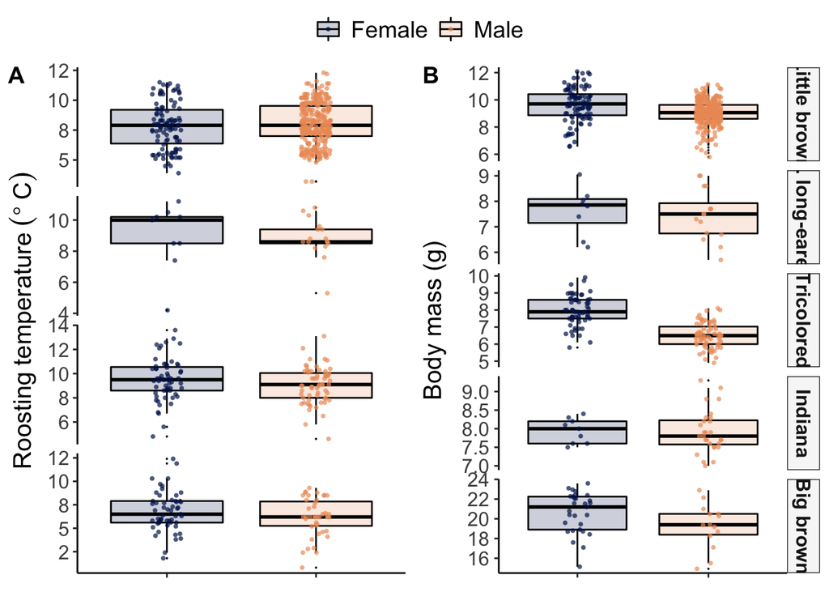